# DA5020 – Assignment 4

```r
library(readr)
library(stringr)
library(lubridate)
library(tidyr)
library(plyr)
library(dplyr)
```

#### 14.2.5.1 - In code that doesn’t use stringr, you’ll often see paste() and paste0(). What’s the difference between the two functions? What stringr function are they equivalent to? How do the functions differ in their handling of NA?

`paste()` adds a space between strings by default and allows specifying a different separator.

```r
paste("this", "is", "a", "string")
```

```
[1] "this is a string"
```

```r
paste("this", "is", "a", "string", sep = ", ")
```

```
[1] "this, is, a, string"
```

`paste0()` does not add or allow a separator (a separator needs to be included in the strings).

```r
paste0("this", "is", "a", "string")
```

```
[1] "thisisastring"
```

```r
paste0("this", "is", "a", "string", sep = ", ")
```

```
[1] "thisisastring, "
```

`paste()` and `paste0()` will include `NA` as part of their output.

```r
paste("this", "is", "a", "string", NA)
```

```
[1] "this is a string NA"
```

```r
paste0("this", "is", "a", "string", NA)
```

```
[1] "thisisastringNA"
```

The functionality of `paste()` and `paste0()` are equivalent to `stringr::str_c()`, with a difference being that `str_c()` will return `NA` if the input contains `NA`.

```r
str_c("this", "is", "a", "string")
```

```
[1] "thisisastring"
```

```r
str_c("this", "is", "a", "string", sep = " ")
```

```
[1] "this is a string"
```

```r
str_c("this", "is", "a", "string", NA)
```

```
[1] NA
```

#### 14.2.5.2 - In your own words, describe the difference between the `sep` and `collapse` arguments to `str_c()`

*`collapse` is used to indicate a separator when concatenating a vector argument to `str_c()`. `sep` is used to indicate a separator when concatenating non-vectorized string arguments to `str_c()`*

```r
str_c(c("I", "was", "a", "vector"), collapse = " ")
```

```
[1] "I was a vector"
```

```r
str_c("I", "was", "not", "a", "vector", sep = " ")
```

```
[1] "I was not a vector"
```

#### 14.2.5.3 - Use `str_length()` and `str_sub()` to extract the middle character from a string. What will you do if the string has an even number of characters?

```r
## odd length
a   <- "pineapple"
mid <- ceiling(str_length(a)/2)

## middle char
str_sub(a,
        mid,
        mid)
```

```
[1] "a"
```

```r
## even length
b    <- "strawberry"

## middle chars
half <- str_length(b)/2
str_sub(b,
        half,
        half + 1)
```

```
[1] "wb"
```

#### 14.2.5.4 - What does str_wrap() do? When might you want to use it?

*`str_wrap()` inserts a new line character at pre-defined intervals allowing for predictable line widths when printing. This could be useful when rendering text in R-based applications like those created with Shiny.*

```r
cat(
  str_wrap("It is a period of civil war. Rebel spaceships, striking from a hidden base, have won their first victory against the evil Galactic Empire.", width = 20)
)
```

```
It is a period of
civil war. Rebel
spaceships, striking
from a hidden base,
have won their first
victory against
the evil Galactic
Empire.
```

#### 14.2.5.5 - What does str_trim() do? What’s the opposite of str_trim()?

*`str_trim()` removes white spaces flanking strings, either on the lef, right, or both. The opposite of str_trim() is `str_pad()`*

```r
str_trim("  hello ")
```

```
[1] "hello"
```

```r
str_pad("goodbye", 20, side = "both")
```

```
[1] "      goodbye       "
```

#### 14.2.5.6 - Write a function that turns (e.g.) a vector c(“a”, “b”, “c”) into the string a, b, and c. Think carefully about what it should do if given a vector of length 0, 1, or 2.

```r
## by definition this function should not accept inputs with lengths < 2
## because the output is expected to be "<a>, and <b>" at minimum
string_fn <- function(x) {
  if (length(x) > 1) {
    str_c(
      str_c(x[1:length(x) - 1], collapse = ", "), ", and ", x[length(x)]
    )
  } else if (length(x) == 1){ ## but we can accomodate length == 1
    str_c(x)
  } else {
    "Not a valid input."
  }
}

string_fn(c())
```

```
[1] "Not a valid input."
```

```r
string_fn(c("a"))
```

```
[1] "a"
```

```r
string_fn(c("a", "b"))
```

```
[1] "a, and b"
```

```r
string_fn(c("a", "b", "c"))
```

```
[1] "a, b, and c"
```

```r
string_fn(c("a", "b", "c", "banana"))
```

```
[1] "a, b, c, and banana"
```

## Question 2.1

Load the data into an appropriate data object of your choice (dataframe or tibble). Note that the data file is compressed so you need to determine an appropriate way to extract the file (this must be done programmatically).

```r
temp <- tempfile()
download.file(url = "http://ds4100.weebly.com/uploads/8/6/5/9/8659576/bird_strikes.zip",
              destfile = temp)
bird_strikes <- read_csv(unzip(zipfile = temp),
                                   na = c("", "NA"),
                         guess_max = 90000)
unlink(temp)
```

## Question 2.2

Create a function called formatColNames() that takes a list of column names as the argument, and uses a regular expression to format the column names in the dataframe or tibble. Ensure that the column names use snake case e.g Number.of.people.injured should be number_of_people_injured.

```r
formatColNames <- function(x) {
  gsub(" |\\.|:", "_", str_to_lower(colnames(bird_strikes)))
}
colnames(bird_strikes) <- colnames(bird_strikes) %>% formatColNames()
colnames(bird_strikes)[1:12]
```

```
 [1] "aircraft__type"               "airport__name"                "altitude_bin"                 "aircraft__make/model"
 [5] "wildlife__number_struck"      "effect__impact_to_flight"     "effect__other"                "location__nearby_if_en_route"
 [9] "aircraft__flight_number"      "flightdate"                   "record_id"                    "effect__indicated_damage"
```

## Question 2.3

Create a function called EventTimeOfDay() that takes when_time_hhmm as an argument and convert it to hours and minutes.

```r
EventTimeOfDay <- function(x) {
  gsub("^(.*)(.{2})$", "\\1:\\2", x)
}
bird_strikes$`when__time_(hhmm)` %>%
  na.omit() %>%
  EventTimeOfDay() %>%
  head(24)
```

```
 [1] "9:43"  "13:00" "11:05" "10:27" "13:45" "7:40"  "20:00" "15:30" "14:43" "16:50" "13:12" "20:00" "8:10"  "12:40" "15:37"
[16] "13:30" "15:39" "17:22" "14:37" "7:45"  "12:20" "8:42"  "17:21" "18:30"
```

## Question 2.4 (a, b, c, d)

```r
strike_event_fn <- function(x) {

  record <- bird_strikes %>% filter(record_id == x)

  ## a
  event_time         <- record %>% pull(`when__time_(hhmm)`) %>% EventTimeOfDay()

  ## b
  date_of_flight     <- record %>% pull(flightdate) %>% mdy_hm() %>% date()

  ## c
  total_inj_and_fatl <- record %>% select(number_of_human_fatalities,
                                          number_of_people_injured) %>%
                                                as.numeric() %>% sum()

  ## iv / d
  aircraft_flight_number    <- record %>% pull(aircraft__flight_number)
  aircraft_make_model       <- record %>% pull(`aircraft__make/model`)
  when_phase_of_flight      <- record %>% pull(when__phase_of_flight)
  origin_state              <- record %>% pull(origin_state)
  airport_name              <- record %>% pull(airport__name)
  conditions_sky            <- record %>% pull(conditions__sky)
  wildlife_size             <- record %>% pull(wildlife__size)
  wildlife_species          <- record %>% pull(wildlife__species)
  aircraft_airline_operator <- record %>% pull(`aircraft__airline/operator`)
  effect_indicated_damage   <- record %>% pull(effect__indicated_damage)

  pilot_warned_of_birds_or_wildlife <-
    record %>% pull(`pilot_warned_of_birds_or_wildlife?`)

  cost_aircraft_time_out_of_service_hours <-
    record %>% pull(`cost__aircraft_time_out_of_service_(hours)`)

  cat(
      str_wrap(
        paste(
        "A bird/wildlife strike event occurred on flight: ", aircraft_flight_number, ", ",
        "aircraft make/model: ", aircraft_make_model, ", on ", date_of_flight, ", ",
        "at ", event_time, " during the ", when_phase_of_flight, " phase of flight. The aircraft
        was operated by ", aircraft_airline_operator, " and originated from ", origin_state, " / ",
        airport_name, ". The sky conditions were ", conditions_sky, ". The wildlife encountered was ",
        wildlife_size, " ", wildlife_species, ". Pilot notified about wildlife: ",
        pilot_warned_of_birds_or_wildlife, ". Damage to aircraft: ", effect_indicated_damage,
        ". The aircraft will be out of service for ", cost_aircraft_time_out_of_service_hours,
        " hours. Total injuries and fatalities: ", total_inj_and_fatl, ".",
        sep = ""
        ),
        width = 80
      )
    )
}
strike_event_fn(203926)
```

```
A bird/wildlife strike event occurred on flight: NA, aircraft make/model:
DA-2000, on 2000-01-02, at 11:05 during the Approach phase of flight. The
aircraft was operated by BUSINESS and originated from Florida / MIAMI INTL. The
sky conditions were No Cloud. The wildlife encountered was Medium Unknown bird
- medium. Pilot notified about wildlife: Y. Damage to aircraft: No damage. The
aircraft will be out of service for NA hours. Total injuries and fatalities: NA.
```

## Question 2.5 –

**original, unrevised question (paraphrased)**  
Create a function called strikesByYear() that takes a user-defined year as a parameter and returns the median bird and wildlife strike events for each month in that year, grouped by the when_time_of_day and when__phase_of_flight. The results should be displayed as a bar chart (Hint: you can use facet_wrap to display the charts) — (15 points)

| when__time_of_day | when__phase_of_flight | phase_strikes | month | monthly_strikes | monthly_time_median |
| --- | --- | --- | --- | --- | --- |
| Dawn | Approach | 42 | 2 | 617 | 617 |
| Dawn | Approach | 42 | 3 | 530 | 617 |
| Dawn | Approach | 42 | 4 | 528 | 617 |
| Dawn | Approach | 42 | 5 | 302 | 617 |
| Dawn | Approach | 42 | 7 | 1074 | 617 |
| Dawn | Approach | 42 | 8 | 816 | 617 |
| Dawn | Approach | 42 | 9 | 1234 | 617 |
| Dawn | Approach | 42 | 10 | 820 | 617 |
| Dawn | Approach | 42 | 11 | 426 | 617 |
| Dawn | Climb | 44 | 1 | 258 | 617 |

[output cut: 226 more lines]

```
phase_strikes: annual strikes / phase / time of day
month: month number (1-12)
monthly_strikes: strikes / month / phase / time of day
monthly_time_median: median strikes / month / time of day
```

| when__time_of_day | when__phase_of_flight | phase_strikes |
| --- | --- | --- |
| Dawn | Approach | 42 |
| Dawn | Climb | 44 |
| Dawn | Descent | 2 |
| Dawn | En Route | 1 |
| Dawn | Landing Roll | 22 |
| Dawn | Take-off run | 52 |
| Day | Approach | 711 |
| Day | Climb | 401 |
| Day | Descent | 29 |
| Day | En Route | 42 |

[output cut: 18 more lines]

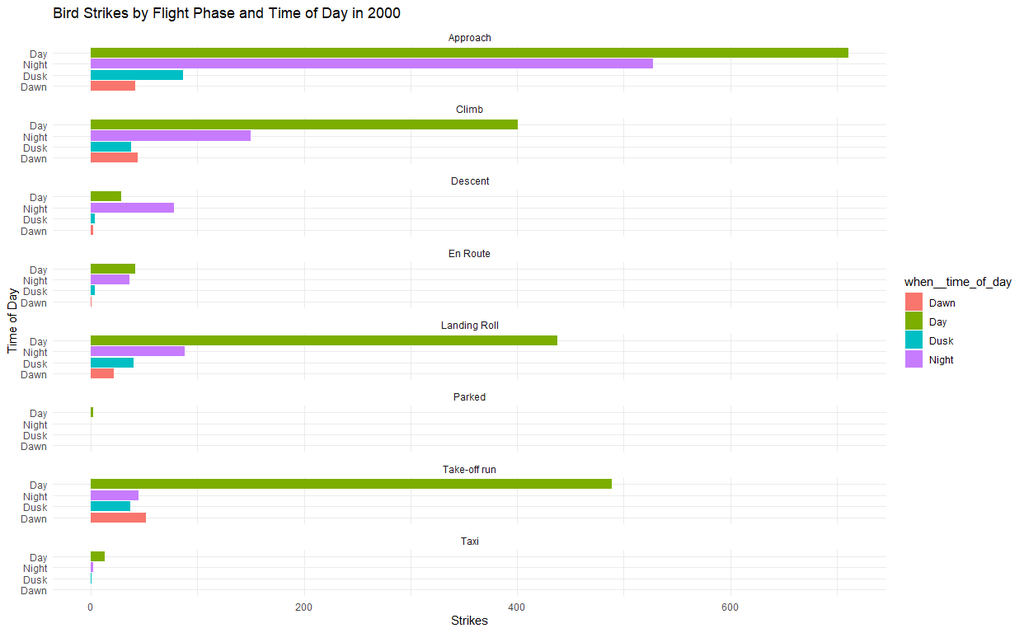

```r
## monthly median by time of day
strikesByYear <- function(x) {
  strikes_median <-
    bird_strikes %>%
      filter(year(mdy_hm(flightdate)) == x,                      ## filter flight date by year
             !grepl("UNKNOWN", when__time_of_day)) %>%           ## remove rows with unknown time of day
      mutate(month = month(mdy_hm(flightdate))) %>%              ## extract month from flight date
      group_by_at(vars(when__time_of_day,                        ## group by time of day then by phase
                       when__phase_of_flight)) %>%
      mutate(phase_strikes = n()) %>%                            ## calculate strikes per phase
      select(when__time_of_day, when__phase_of_flight,           ## select features of interest
             phase_strikes, month) %>%
      drop_na() %>% ungroup() %>%                                ## remove NAs and ungroup
      group_by(when__time_of_day, month) %>%                     ## regroup by time of day then month
      mutate(monthly_strikes = sum(phase_strikes)) %>%           ## calculate strikes per month
      ungroup() %>% group_by(when__time_of_day) %>% distinct %>% ## ungroup and regroup by time only
      mutate(monthly_time_median = median(monthly_strikes)) %>%  ## calculate median monthly strikes by phase
      ungroup %>% arrange(when__time_of_day,                     ## nice and neat
                          when__phase_of_flight)
  strikes_by_phase <-
    strikes_median %>%
    select(when__time_of_day,
           when__phase_of_flight,
           phase_strikes) %>%
    distinct()

        phase_plot <-
          ggplot(strikes_by_phase,
               aes(x = when__time_of_day,
                   y = phase_strikes,
                   fill = when__time_of_day)) +
          geom_bar(stat = "identity") +
          facet_wrap(~when__phase_of_flight, ncol = 1) +
          theme_minimal() +
          coord_flip() +
          labs(title = str_c("Bird Strikes by Flight Phase and Time of Day in ", x),
               x     = "Time of Day",
               y     = "Strikes") +
          scale_x_discrete(limits = rev(c("Day", "Night", "Dusk", "Dawn")))
        print(strikes_median)
        cat(
            "phase_strikes: annual strikes / phase / time of day",
            "month: month number (1-12)",
            "monthly_strikes: strikes / month / phase / time of day",
            "monthly_time_median: median strikes / month / time of day",
            sep = "\n"
            )
        print(strikes_by_phase)
        print(phase_plot)
}
strikesByYear(2000)
```

## Question 2.6

Is it always practical to impute missing values? E.g. think about what would happen if the aircraft_flight_number or number_of_human_fatalities are missing, and you choose to impute a value for it.

*It is not always practical to impute missing values, and inappropriately imputing values may make the data significantly misleading. It would not be appropriate to impute aircraft_flight_number because this is an identifier not used for classification*